# SQ 030

## Shared Qs (030)

#### Question

1. Let $x(t)$ represent a train’s position as a function of time. For some train during some period of time, the position can be modeled with a quadratic function.

   $$x(t) = 6t^2+5t-10$$

   The velocity $v(t)$ is also a function of time. The velocity function is the [**derivative**](https://en.wikipedia.org/wiki/Derivative#As_a_limit) (with respect to time) of the position function. The derivative can be defined using a limit.

   $$v(t) ~=~ \lim_{h\to 0}\frac{x(t+h)-x(t)}{h}$$

   Using this definition (and simplifying), you will find that $v(t)$ is a linear function in time, which depends on the acceleration $a$ and the initial velocity $v_0$.

   $$v(t) ~=~ at+v_0$$

   Determine $a$ and $v_0$.
   - $a=$
   - $v_0=$

#### Solution

#### Question

2. Let $x(t)$ represent a train’s position as a function of time. For some train during some period of time, the position can be modeled with a quadratic function.

   $$x(t) = 4t^2-8t+5$$

   The velocity $v(t)$ is also a function of time. The velocity function is the [**derivative**](https://en.wikipedia.org/wiki/Derivative#As_a_limit) (with respect to time) of the position function. The derivative can be defined using a limit.

   $$v(t) ~=~ \lim_{h\to 0}\frac{x(t+h)-x(t)}{h}$$

   Using this definition (and simplifying), you will find that $v(t)$ is a linear function in time, which depends on the acceleration $a$ and the initial velocity $v_0$.

   $$v(t) ~=~ at+v_0$$

   Determine $a$ and $v_0$.
   - $a=$
   - $v_0=$

#### Solution

#### Question

3. Let $x(t)$ represent a train’s position as a function of time. For some train during some period of time, the position can be modeled with a quadratic function.

   $$x(t) = 3t^2+5t+9$$

   The velocity $v(t)$ is also a function of time. The velocity function is the [**derivative**](https://en.wikipedia.org/wiki/Derivative#As_a_limit) (with respect to time) of the position function. The derivative can be defined using a limit.

   $$v(t) ~=~ \lim_{h\to 0}\frac{x(t+h)-x(t)}{h}$$

   Using this definition (and simplifying), you will find that $v(t)$ is a linear function in time, which depends on the acceleration $a$ and the initial velocity $v_0$.

   $$v(t) ~=~ at+v_0$$

   Determine $a$ and $v_0$.
   - $a=$
   - $v_0=$

#### Solution

#### Question

4. Let $x(t)$ represent a train’s position as a function of time. For some train during some period of time, the position can be modeled with a quadratic function.

   $$x(t) = -10t^2-9t-4$$

   The velocity $v(t)$ is also a function of time. The velocity function is the [**derivative**](https://en.wikipedia.org/wiki/Derivative#As_a_limit) (with respect to time) of the position function. The derivative can be defined using a limit.

   $$v(t) ~=~ \lim_{h\to 0}\frac{x(t+h)-x(t)}{h}$$

   Using this definition (and simplifying), you will find that $v(t)$ is a linear function in time, which depends on the acceleration $a$ and the initial velocity $v_0$.

   $$v(t) ~=~ at+v_0$$

   Determine $a$ and $v_0$.
   - $a=$
   - $v_0=$

#### Solution

#### Question

5. Let $x(t)$ represent a train’s position as a function of time. For some train during some period of time, the position can be modeled with a quadratic function.

   $$x(t) = -3t^2-10t+2$$

   The velocity $v(t)$ is also a function of time. The velocity function is the [**derivative**](https://en.wikipedia.org/wiki/Derivative#As_a_limit) (with respect to time) of the position function. The derivative can be defined using a limit.

   $$v(t) ~=~ \lim_{h\to 0}\frac{x(t+h)-x(t)}{h}$$

   Using this definition (and simplifying), you will find that $v(t)$ is a linear function in time, which depends on the acceleration $a$ and the initial velocity $v_0$.

   $$v(t) ~=~ at+v_0$$

   Determine $a$ and $v_0$.
   - $a=$
   - $v_0=$

#### Solution

#### Question

6. A train’s position $x(t)$ as a function of time $t$ can be modeled with a cubic function.
   $$x(t) = -5t^3-10t^2-2t-7$$

   The velocity $v(t)$ is also a function of time. The velocity function is the [**derivative**](https://en.wikipedia.org/wiki/Derivative#As_a_limit) (with respect to time) of the position function. The derivative can be defined using a limit.

   $$v(t) ~=~ \lim_{h\to 0}\frac{x(t+h)-x(t)}{h}$$

   Using this definition (and simplifying), you will find that $v(t)$ is a quadratic function in time.

   $$v(t) ~=~ pt^2+qt+r$$

   Determine $p$ and $q$ and $r$.
   - $p=$
   - $q=$
   - $r=$

   The acceleration is the **derivative** of velocity.

   $$a(t) = \lim_{h\to 0} \frac{v(t+h)-v(t)}{h}$$

   Using this definition (and simplifying), you will find that $a(t)$ is a linear function in time.

   $$a(t)~=~jt+a_0$$

   where $j$ is the jerk and $a_0$ is the initial acceleration.

   Determine $j$ and $a_0$.
   - $j=$
   - $a_0=$

#### Solution

#### Question

7. A train’s position $x(t)$ as a function of time $t$ can be modeled with a cubic function.
   $$x(t) = 5t^3-4t^2+10t-3$$

   The velocity $v(t)$ is also a function of time. The velocity function is the [**derivative**](https://en.wikipedia.org/wiki/Derivative#As_a_limit) (with respect to time) of the position function. The derivative can be defined using a limit.

   $$v(t) ~=~ \lim_{h\to 0}\frac{x(t+h)-x(t)}{h}$$

   Using this definition (and simplifying), you will find that $v(t)$ is a quadratic function in time.

   $$v(t) ~=~ pt^2+qt+r$$

   Determine $p$ and $q$ and $r$.
   - $p=$
   - $q=$
   - $r=$

   The acceleration is the **derivative** of velocity.

   $$a(t) = \lim_{h\to 0} \frac{v(t+h)-v(t)}{h}$$

   Using this definition (and simplifying), you will find that $a(t)$ is a linear function in time.

   $$a(t)~=~jt+a_0$$

   where $j$ is the jerk and $a_0$ is the initial acceleration.

   Determine $j$ and $a_0$.
   - $j=$
   - $a_0=$

#### Solution

#### Question

8. A train’s position $x(t)$ as a function of time $t$ can be modeled with a cubic function.
   $$x(t) = 2t^3-7t^2+5t+8$$

   The velocity $v(t)$ is also a function of time. The velocity function is the [**derivative**](https://en.wikipedia.org/wiki/Derivative#As_a_limit) (with respect to time) of the position function. The derivative can be defined using a limit.

   $$v(t) ~=~ \lim_{h\to 0}\frac{x(t+h)-x(t)}{h}$$

   Using this definition (and simplifying), you will find that $v(t)$ is a quadratic function in time.

   $$v(t) ~=~ pt^2+qt+r$$

   Determine $p$ and $q$ and $r$.
   - $p=$
   - $q=$
   - $r=$

   The acceleration is the **derivative** of velocity.

   $$a(t) = \lim_{h\to 0} \frac{v(t+h)-v(t)}{h}$$

   Using this definition (and simplifying), you will find that $a(t)$ is a linear function in time.

   $$a(t)~=~jt+a_0$$

   where $j$ is the jerk and $a_0$ is the initial acceleration.

   Determine $j$ and $a_0$.
   - $j=$
   - $a_0=$

#### Solution

#### Question

9. A train’s position $x(t)$ as a function of time $t$ can be modeled with a cubic function.
   $$x(t) = -5t^3+2t^2+4t+3$$

   The velocity $v(t)$ is also a function of time. The velocity function is the [**derivative**](https://en.wikipedia.org/wiki/Derivative#As_a_limit) (with respect to time) of the position function. The derivative can be defined using a limit.

   $$v(t) ~=~ \lim_{h\to 0}\frac{x(t+h)-x(t)}{h}$$

   Using this definition (and simplifying), you will find that $v(t)$ is a quadratic function in time.

   $$v(t) ~=~ pt^2+qt+r$$

   Determine $p$ and $q$ and $r$.
   - $p=$
   - $q=$
   - $r=$

   The acceleration is the **derivative** of velocity.

   $$a(t) = \lim_{h\to 0} \frac{v(t+h)-v(t)}{h}$$

   Using this definition (and simplifying), you will find that $a(t)$ is a linear function in time.

   $$a(t)~=~jt+a_0$$

   where $j$ is the jerk and $a_0$ is the initial acceleration.

   Determine $j$ and $a_0$.
   - $j=$
   - $a_0=$

#### Solution

#### Question

10. A train’s position $x(t)$ as a function of time $t$ can be modeled with a cubic function.
    $$x(t) = -2t^3-5t^2+4t-7$$

    The velocity $v(t)$ is also a function of time. The velocity function is the [**derivative**](https://en.wikipedia.org/wiki/Derivative#As_a_limit) (with respect to time) of the position function. The derivative can be defined using a limit.

    $$v(t) ~=~ \lim_{h\to 0}\frac{x(t+h)-x(t)}{h}$$

    Using this definition (and simplifying), you will find that $v(t)$ is a quadratic function in time.

    $$v(t) ~=~ pt^2+qt+r$$

    Determine $p$ and $q$ and $r$.
    - $p=$
    - $q=$
    - $r=$

    The acceleration is the **derivative** of velocity.

    $$a(t) = \lim_{h\to 0} \frac{v(t+h)-v(t)}{h}$$

    Using this definition (and simplifying), you will find that $a(t)$ is a linear function in time.

    $$a(t)~=~jt+a_0$$

    where $j$ is the jerk and $a_0$ is the initial acceleration.

    Determine $j$ and $a_0$.
    - $j=$
    - $a_0=$

#### Solution

#### Question

11. Let $f(t)=4t^6$. The [derivative](https://en.wikipedia.org/wiki/Derivative) can be defined with a limit.

    $$f'(t) ~=~ \lim_{h\to 0}\frac{f(t+h)-f(t)}{h}$$

    You can prove that $f'(t)=at^b$. What are $a$ and $b$?
    - $a=$
    - $b=$

#### Solution

#### Question

12. Let $f(t)=6t^7$. The [derivative](https://en.wikipedia.org/wiki/Derivative) can be defined with a limit.

    $$f'(t) ~=~ \lim_{h\to 0}\frac{f(t+h)-f(t)}{h}$$

    You can prove that $f'(t)=at^b$. What are $a$ and $b$?
    - $a=$
    - $b=$

#### Solution

#### Question

13. Let $f(t)=9t^5$. The [derivative](https://en.wikipedia.org/wiki/Derivative) can be defined with a limit.

    $$f'(t) ~=~ \lim_{h\to 0}\frac{f(t+h)-f(t)}{h}$$

    You can prove that $f'(t)=at^b$. What are $a$ and $b$?
    - $a=$
    - $b=$

#### Solution

#### Question

14. Let $f(t)=7t^6$. The [derivative](https://en.wikipedia.org/wiki/Derivative) can be defined with a limit.

    $$f'(t) ~=~ \lim_{h\to 0}\frac{f(t+h)-f(t)}{h}$$

    You can prove that $f'(t)=at^b$. What are $a$ and $b$?
    - $a=$
    - $b=$

#### Solution

#### Question

15. Let $f(t)=9t^5$. The [derivative](https://en.wikipedia.org/wiki/Derivative) can be defined with a limit.

    $$f'(t) ~=~ \lim_{h\to 0}\frac{f(t+h)-f(t)}{h}$$

    You can prove that $f'(t)=at^b$. What are $a$ and $b$?
    - $a=$
    - $b=$

#### Solution

#### Question

16. First, we can prove that if $f(t) = m(t)+n(t)$ then $f'(t) = m'(t)+n'(t)$. In other words, the derivative of a sum equals the sum of the derivatives. Or, in other words, [differentiation is linear](https://en.wikipedia.org/wiki/Linearity_of_differentiation). The proof follows.

    $$f'(t) = \lim_{h\to 0}\frac{f(t+h)-f(t)}{h}$$
    $$f'(t) = \lim_{h\to 0}\frac{\left(m(t+h)+n(t+h)\right)-\left(m(t)+n(t)\right)}{h}$$
    $$f'(t) = \lim_{h\to 0}\frac{\left(m(t+h)-m(t)\right)+\left(n(t+h)-n(t)\right)}{h}$$
    $$f'(t) = \lim_{h\to 0}\left(\frac{m(t+h)-m(t)}{h}+\frac{n(t+h)-n(t)}{h}\right)$$
    $$f'(t) = \lim_{h\to 0}\frac{m(t+h)-m(t)}{h}+\lim_{h\to 0}\frac{n(t+h)-n(t)}{h}$$
    $$f'(t) = m'(t)+n'(t)$$

    Also, if $g(t) = at^b$ then $g'(t) = (ab)t^{b-1}$. In other words, the derivative of a power function is found by multiplying the coefficient by the power and then reducing the power by one.

    Let $f(t)$ be a function defined below:
    $$f(t)~=~7.2t^{9.1}+4.1t^{2.5}$$

    Using the rules above, find $f'(0.44)$. The tolerance is $\pm 0.01$.

#### Solution

#### Question

17. First, we can prove that if $f(t) = m(t)+n(t)$ then $f'(t) = m'(t)+n'(t)$. In other words, the derivative of a sum equals the sum of the derivatives. Or, in other words, [differentiation is linear](https://en.wikipedia.org/wiki/Linearity_of_differentiation). The proof follows.

    $$f'(t) = \lim_{h\to 0}\frac{f(t+h)-f(t)}{h}$$
    $$f'(t) = \lim_{h\to 0}\frac{\left(m(t+h)+n(t+h)\right)-\left(m(t)+n(t)\right)}{h}$$
    $$f'(t) = \lim_{h\to 0}\frac{\left(m(t+h)-m(t)\right)+\left(n(t+h)-n(t)\right)}{h}$$
    $$f'(t) = \lim_{h\to 0}\left(\frac{m(t+h)-m(t)}{h}+\frac{n(t+h)-n(t)}{h}\right)$$
    $$f'(t) = \lim_{h\to 0}\frac{m(t+h)-m(t)}{h}+\lim_{h\to 0}\frac{n(t+h)-n(t)}{h}$$
    $$f'(t) = m'(t)+n'(t)$$

    Also, if $g(t) = at^b$ then $g'(t) = (ab)t^{b-1}$. In other words, the derivative of a power function is found by multiplying the coefficient by the power and then reducing the power by one.

    Let $f(t)$ be a function defined below:
    $$f(t)~=~4.9t^{4.8}+2.1t^{6.8}$$

    Using the rules above, find $f'(0.92)$. The tolerance is $\pm 0.01$.

#### Solution

#### Question

18. First, we can prove that if $f(t) = m(t)+n(t)$ then $f'(t) = m'(t)+n'(t)$. In other words, the derivative of a sum equals the sum of the derivatives. Or, in other words, [differentiation is linear](https://en.wikipedia.org/wiki/Linearity_of_differentiation). The proof follows.

    $$f'(t) = \lim_{h\to 0}\frac{f(t+h)-f(t)}{h}$$
    $$f'(t) = \lim_{h\to 0}\frac{\left(m(t+h)+n(t+h)\right)-\left(m(t)+n(t)\right)}{h}$$
    $$f'(t) = \lim_{h\to 0}\frac{\left(m(t+h)-m(t)\right)+\left(n(t+h)-n(t)\right)}{h}$$
    $$f'(t) = \lim_{h\to 0}\left(\frac{m(t+h)-m(t)}{h}+\frac{n(t+h)-n(t)}{h}\right)$$
    $$f'(t) = \lim_{h\to 0}\frac{m(t+h)-m(t)}{h}+\lim_{h\to 0}\frac{n(t+h)-n(t)}{h}$$
    $$f'(t) = m'(t)+n'(t)$$

    Also, if $g(t) = at^b$ then $g'(t) = (ab)t^{b-1}$. In other words, the derivative of a power function is found by multiplying the coefficient by the power and then reducing the power by one.

    Let $f(t)$ be a function defined below:
    $$f(t)~=~8.9t^{4.3}+2t^{7.5}$$

    Using the rules above, find $f'(0.5)$. The tolerance is $\pm 0.01$.

#### Solution

#### Question

19. First, we can prove that if $f(t) = m(t)+n(t)$ then $f'(t) = m'(t)+n'(t)$. In other words, the derivative of a sum equals the sum of the derivatives. Or, in other words, [differentiation is linear](https://en.wikipedia.org/wiki/Linearity_of_differentiation). The proof follows.

    $$f'(t) = \lim_{h\to 0}\frac{f(t+h)-f(t)}{h}$$
    $$f'(t) = \lim_{h\to 0}\frac{\left(m(t+h)+n(t+h)\right)-\left(m(t)+n(t)\right)}{h}$$
    $$f'(t) = \lim_{h\to 0}\frac{\left(m(t+h)-m(t)\right)+\left(n(t+h)-n(t)\right)}{h}$$
    $$f'(t) = \lim_{h\to 0}\left(\frac{m(t+h)-m(t)}{h}+\frac{n(t+h)-n(t)}{h}\right)$$
    $$f'(t) = \lim_{h\to 0}\frac{m(t+h)-m(t)}{h}+\lim_{h\to 0}\frac{n(t+h)-n(t)}{h}$$
    $$f'(t) = m'(t)+n'(t)$$

    Also, if $g(t) = at^b$ then $g'(t) = (ab)t^{b-1}$. In other words, the derivative of a power function is found by multiplying the coefficient by the power and then reducing the power by one.

    Let $f(t)$ be a function defined below:
    $$f(t)~=~4.9t^{4.4}+3.3t^{1.2}$$

    Using the rules above, find $f'(0.86)$. The tolerance is $\pm 0.01$.

#### Solution

#### Question

20. First, we can prove that if $f(t) = m(t)+n(t)$ then $f'(t) = m'(t)+n'(t)$. In other words, the derivative of a sum equals the sum of the derivatives. Or, in other words, [differentiation is linear](https://en.wikipedia.org/wiki/Linearity_of_differentiation). The proof follows.

    $$f'(t) = \lim_{h\to 0}\frac{f(t+h)-f(t)}{h}$$
    $$f'(t) = \lim_{h\to 0}\frac{\left(m(t+h)+n(t+h)\right)-\left(m(t)+n(t)\right)}{h}$$
    $$f'(t) = \lim_{h\to 0}\frac{\left(m(t+h)-m(t)\right)+\left(n(t+h)-n(t)\right)}{h}$$
    $$f'(t) = \lim_{h\to 0}\left(\frac{m(t+h)-m(t)}{h}+\frac{n(t+h)-n(t)}{h}\right)$$
    $$f'(t) = \lim_{h\to 0}\frac{m(t+h)-m(t)}{h}+\lim_{h\to 0}\frac{n(t+h)-n(t)}{h}$$
    $$f'(t) = m'(t)+n'(t)$$

    Also, if $g(t) = at^b$ then $g'(t) = (ab)t^{b-1}$. In other words, the derivative of a power function is found by multiplying the coefficient by the power and then reducing the power by one.

    Let $f(t)$ be a function defined below:
    $$f(t)~=~8.4t^{7.9}+4.2t^{9.7}$$

    Using the rules above, find $f'(0.29)$. The tolerance is $\pm 0.01$.

#### Solution

#### Question

21. Consider the polynomial function below.
    $$f(x)=-8x^{5}+10x^{4}$$

    Determine
    $$f''(-0.24)$$
    . The tolerance is $\pm0.01$.

#### Solution

#### Question

22. Consider the polynomial function below.
    $$f(x)=12x^{10}-6x^{7}$$

    Determine
    $$f''(-0.34)$$
    . The tolerance is $\pm0.01$.

#### Solution

#### Question

23. Consider the polynomial function below.
    $$f(x)=4x^{11}-10x^{12}$$

    Determine
    $$f''(-0.36)$$
    . The tolerance is $\pm0.01$.

#### Solution

#### Question

24. Consider the polynomial function below.
    $$f(x)=-8x^{7}-4x^{6}$$

    Determine
    $$f''(0.4)$$
    . The tolerance is $\pm0.01$.

#### Solution

#### Question

25. Consider the polynomial function below.
    $$f(x)=-7x^{10}-4x^{5}$$

    Determine
    $$f''(-0.28)$$
    . The tolerance is $\pm0.01$.

#### Solution

#### Question

26. A bucket initially holds 8.1 liters of water. A hole is punched into the bottom of the bucket, so water leaks out following [Torricelli’s law](https://en.wikipedia.org/wiki/Torricelli%27s_law). Below, volume is shown as a function of time, where $t$ in in minutes.

    $$V(t)~=~1t^2-5.7t+8.1$$

    How fast (in liters per minute) is water leaving the bucket at $t=2.23$ minutes? (Tolerance is $\pm 0.01$ liters per minute.) The volume in the bucket is decreasing, so the derivative will be negative, but the question is asking about the rate of water leaving, so your answer should be positive.

#### Solution

#### Question

27. A bucket initially holds 4.2 liters of water. A hole is punched into the bottom of the bucket, so water leaks out following [Torricelli’s law](https://en.wikipedia.org/wiki/Torricelli%27s_law). Below, volume is shown as a function of time, where $t$ in in minutes.

    $$V(t)~=~3.2t^2-7.3t+4.2$$

    How fast (in liters per minute) is water leaving the bucket at $t=0.69$ minutes? (Tolerance is $\pm 0.01$ liters per minute.) The volume in the bucket is decreasing, so the derivative will be negative, but the question is asking about the rate of water leaving, so your answer should be positive.

#### Solution

#### Question

28. A bucket initially holds 13 liters of water. A hole is punched into the bottom of the bucket, so water leaks out following [Torricelli’s law](https://en.wikipedia.org/wiki/Torricelli%27s_law). Below, volume is shown as a function of time, where $t$ in in minutes.

    $$V(t)~=~3.4t^2-13.4t+13$$

    How fast (in liters per minute) is water leaving the bucket at $t=0.22$ minutes? (Tolerance is $\pm 0.01$ liters per minute.) The volume in the bucket is decreasing, so the derivative will be negative, but the question is asking about the rate of water leaving, so your answer should be positive.

#### Solution

#### Question

29. A bucket initially holds 12.7 liters of water. A hole is punched into the bottom of the bucket, so water leaks out following [Torricelli’s law](https://en.wikipedia.org/wiki/Torricelli%27s_law). Below, volume is shown as a function of time, where $t$ in in minutes.

    $$V(t)~=~1.2t^2-7.8t+12.7$$

    How fast (in liters per minute) is water leaving the bucket at $t=1.99$ minutes? (Tolerance is $\pm 0.01$ liters per minute.) The volume in the bucket is decreasing, so the derivative will be negative, but the question is asking about the rate of water leaving, so your answer should be positive.

#### Solution

#### Question

30. A bucket initially holds 13.3 liters of water. A hole is punched into the bottom of the bucket, so water leaks out following [Torricelli’s law](https://en.wikipedia.org/wiki/Torricelli%27s_law). Below, volume is shown as a function of time, where $t$ in in minutes.

    $$V(t)~=~0.6t^2-5.5t+13.3$$

    How fast (in liters per minute) is water leaving the bucket at $t=4.24$ minutes? (Tolerance is $\pm 0.01$ liters per minute.) The volume in the bucket is decreasing, so the derivative will be negative, but the question is asking about the rate of water leaving, so your answer should be positive.

#### Solution

#### Question

31. A human converts [chemical energy](https://en.wikipedia.org/wiki/Chemical_energy) (energy stored as ATP and carbohydrates) into [gravitational potential energy](https://en.wikipedia.org/wiki/Gravitational_energy) by pedaling a bicycle up a hill. During a short burst, the amount of work (stored as potential energy), as a function of time, follows the polynomial expression below, where energy ($E$) is in [joules](https://en.wikipedia.org/wiki/Joule) and time ($t$) is in [seconds](https://en.wikipedia.org/wiki/Second).
    $$E(t) ~=~ 1.79t^4-48.18t^3+364.61t^2+44.69t$$

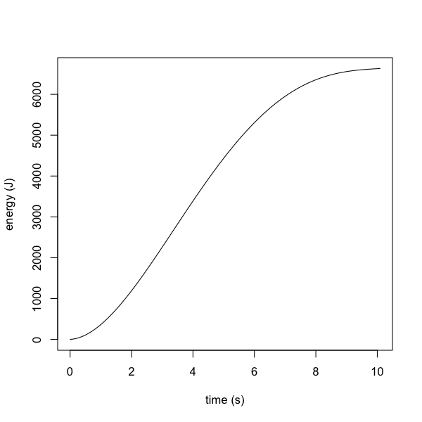

    For your reference, 4184 joules is 1 kilocalorie ([and in the US, in regards to food, we call 1 kilocalorie a “calorie”… just to be as confused as possible](https://en.wikipedia.org/wiki/Calorie#Food_energy)).

    Power is the rate of energy per time. In this case, we will measure power in [watts](https://en.wikipedia.org/wiki/Watt), where 1 watt equals 1 joule per second. A human burns 100 watts as [basal metabolism](https://en.wikipedia.org/wiki/Basal_metabolic_rate). Walking burns an additional 30 watts. A professional cyclist can maintain 400 watts of output while racing (see [Human Power](https://en.wikipedia.org/wiki/Human_power#Available_power)). A typical college-aged student can output 1000 watts for a few seconds. Usain Bolt’s record sprint required a burst of 2500 watts (about 3.5 horsepower) for part of the sprint. Throughout history, a laborer would average about 100 watts above basal metabolism (see [Vaclav Smil](https://vaclavsmil.com/wp-content/uploads/docs/smil-articles-science-energy-ethics-civilization.pdf)).

    Anyway, at $t=5.5$ seconds, what is the power output of the human in watts? The tolerance is $\pm 1$ watt.

#### Solution

#### Question

32. A human converts [chemical energy](https://en.wikipedia.org/wiki/Chemical_energy) (energy stored as ATP and carbohydrates) into [gravitational potential energy](https://en.wikipedia.org/wiki/Gravitational_energy) by pedaling a bicycle up a hill. During a short burst, the amount of work (stored as potential energy), as a function of time, follows the polynomial expression below, where energy ($E$) is in [joules](https://en.wikipedia.org/wiki/Joule) and time ($t$) is in [seconds](https://en.wikipedia.org/wiki/Second).
    $$E(t) ~=~ 0.72t^4-24.81t^3+238.81t^2+67.49t$$

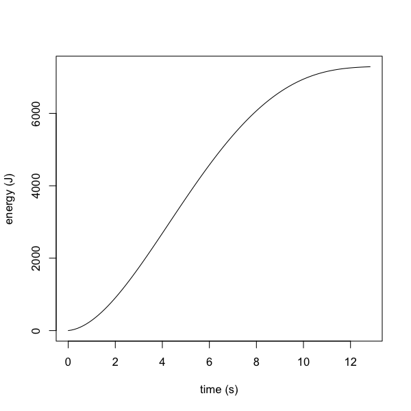

    For your reference, 4184 joules is 1 kilocalorie ([and in the US, in regards to food, we call 1 kilocalorie a “calorie”… just to be as confused as possible](https://en.wikipedia.org/wiki/Calorie#Food_energy)).

    Power is the rate of energy per time. In this case, we will measure power in [watts](https://en.wikipedia.org/wiki/Watt), where 1 watt equals 1 joule per second. A human burns 100 watts as [basal metabolism](https://en.wikipedia.org/wiki/Basal_metabolic_rate). Walking burns an additional 30 watts. A professional cyclist can maintain 400 watts of output while racing (see [Human Power](https://en.wikipedia.org/wiki/Human_power#Available_power)). A typical college-aged student can output 1000 watts for a few seconds. Usain Bolt’s record sprint required a burst of 2500 watts (about 3.5 horsepower) for part of the sprint. Throughout history, a laborer would average about 100 watts above basal metabolism (see [Vaclav Smil](https://vaclavsmil.com/wp-content/uploads/docs/smil-articles-science-energy-ethics-civilization.pdf)).

    Anyway, at $t=6.2$ seconds, what is the power output of the human in watts? The tolerance is $\pm 1$ watt.

#### Solution

#### Question

33. A human converts [chemical energy](https://en.wikipedia.org/wiki/Chemical_energy) (energy stored as ATP and carbohydrates) into [gravitational potential energy](https://en.wikipedia.org/wiki/Gravitational_energy) by pedaling a bicycle up a hill. During a short burst, the amount of work (stored as potential energy), as a function of time, follows the polynomial expression below, where energy ($E$) is in [joules](https://en.wikipedia.org/wiki/Joule) and time ($t$) is in [seconds](https://en.wikipedia.org/wiki/Second).
    $$E(t) ~=~ 0.45t^4-16.27t^3+166.79t^2+34.48t$$

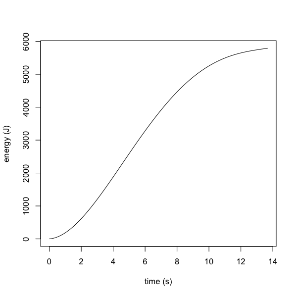

    For your reference, 4184 joules is 1 kilocalorie ([and in the US, in regards to food, we call 1 kilocalorie a “calorie”… just to be as confused as possible](https://en.wikipedia.org/wiki/Calorie#Food_energy)).

    Power is the rate of energy per time. In this case, we will measure power in [watts](https://en.wikipedia.org/wiki/Watt), where 1 watt equals 1 joule per second. A human burns 100 watts as [basal metabolism](https://en.wikipedia.org/wiki/Basal_metabolic_rate). Walking burns an additional 30 watts. A professional cyclist can maintain 400 watts of output while racing (see [Human Power](https://en.wikipedia.org/wiki/Human_power#Available_power)). A typical college-aged student can output 1000 watts for a few seconds. Usain Bolt’s record sprint required a burst of 2500 watts (about 3.5 horsepower) for part of the sprint. Throughout history, a laborer would average about 100 watts above basal metabolism (see [Vaclav Smil](https://vaclavsmil.com/wp-content/uploads/docs/smil-articles-science-energy-ethics-civilization.pdf)).

    Anyway, at $t=1.8$ seconds, what is the power output of the human in watts? The tolerance is $\pm 1$ watt.

#### Solution

#### Question

34. A human converts [chemical energy](https://en.wikipedia.org/wiki/Chemical_energy) (energy stored as ATP and carbohydrates) into [gravitational potential energy](https://en.wikipedia.org/wiki/Gravitational_energy) by pedaling a bicycle up a hill. During a short burst, the amount of work (stored as potential energy), as a function of time, follows the polynomial expression below, where energy ($E$) is in [joules](https://en.wikipedia.org/wiki/Joule) and time ($t$) is in [seconds](https://en.wikipedia.org/wiki/Second).
    $$E(t) ~=~ 0.32t^4-14t^3+172.41t^2+31.34t$$

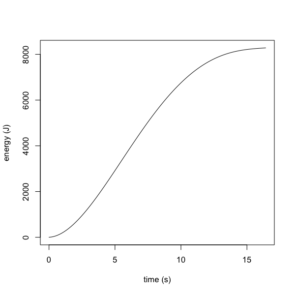

    For your reference, 4184 joules is 1 kilocalorie ([and in the US, in regards to food, we call 1 kilocalorie a “calorie”… just to be as confused as possible](https://en.wikipedia.org/wiki/Calorie#Food_energy)).

    Power is the rate of energy per time. In this case, we will measure power in [watts](https://en.wikipedia.org/wiki/Watt), where 1 watt equals 1 joule per second. A human burns 100 watts as [basal metabolism](https://en.wikipedia.org/wiki/Basal_metabolic_rate). Walking burns an additional 30 watts. A professional cyclist can maintain 400 watts of output while racing (see [Human Power](https://en.wikipedia.org/wiki/Human_power#Available_power)). A typical college-aged student can output 1000 watts for a few seconds. Usain Bolt’s record sprint required a burst of 2500 watts (about 3.5 horsepower) for part of the sprint. Throughout history, a laborer would average about 100 watts above basal metabolism (see [Vaclav Smil](https://vaclavsmil.com/wp-content/uploads/docs/smil-articles-science-energy-ethics-civilization.pdf)).

    Anyway, at $t=14.3$ seconds, what is the power output of the human in watts? The tolerance is $\pm 1$ watt.

#### Solution

#### Question

35. A human converts [chemical energy](https://en.wikipedia.org/wiki/Chemical_energy) (energy stored as ATP and carbohydrates) into [gravitational potential energy](https://en.wikipedia.org/wiki/Gravitational_energy) by pedaling a bicycle up a hill. During a short burst, the amount of work (stored as potential energy), as a function of time, follows the polynomial expression below, where energy ($E$) is in [joules](https://en.wikipedia.org/wiki/Joule) and time ($t$) is in [seconds](https://en.wikipedia.org/wiki/Second).
    $$E(t) ~=~ 1.06t^4-28.31t^3+212.23t^2+64.87t$$

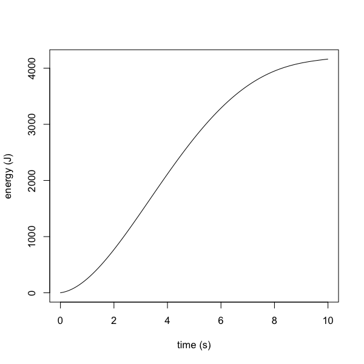

    For your reference, 4184 joules is 1 kilocalorie ([and in the US, in regards to food, we call 1 kilocalorie a “calorie”… just to be as confused as possible](https://en.wikipedia.org/wiki/Calorie#Food_energy)).

    Power is the rate of energy per time. In this case, we will measure power in [watts](https://en.wikipedia.org/wiki/Watt), where 1 watt equals 1 joule per second. A human burns 100 watts as [basal metabolism](https://en.wikipedia.org/wiki/Basal_metabolic_rate). Walking burns an additional 30 watts. A professional cyclist can maintain 400 watts of output while racing (see [Human Power](https://en.wikipedia.org/wiki/Human_power#Available_power)). A typical college-aged student can output 1000 watts for a few seconds. Usain Bolt’s record sprint required a burst of 2500 watts (about 3.5 horsepower) for part of the sprint. Throughout history, a laborer would average about 100 watts above basal metabolism (see [Vaclav Smil](https://vaclavsmil.com/wp-content/uploads/docs/smil-articles-science-energy-ethics-civilization.pdf)).

    Anyway, at $t=2.5$ seconds, what is the power output of the human in watts? The tolerance is $\pm 1$ watt.

#### Solution

#### Question

36. The graph of $y=f(x)$ is shown below. Also, at $x=3$, a [tangent line](https://en.wikipedia.org/wiki/Tangent) is drawn.

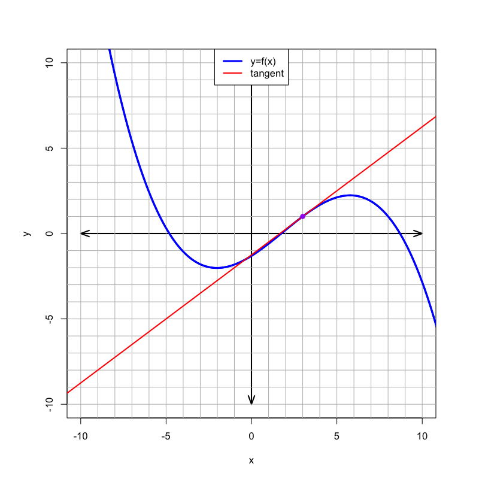

    The tangent line can be used to determine the [instantaneous rate of change](https://en.wikipedia.org/wiki/Derivative) of $f(x)$ at $x=3$.

    Please estimate $f'(3)$ within the nearest hundredth. This could also be notated as $\left.\frac{df(x)}{dx}\right|_{x=3}$ or as $\frac{df}{dx}(3)$. For more, see [wikipedia’s article on notation for differentiation](https://en.wikipedia.org/wiki/Notation_for_differentiation).

#### Solution

#### Question

37. The graph of $y=f(x)$ is shown below. Also, at $x=-2$, a [tangent line](https://en.wikipedia.org/wiki/Tangent) is drawn.

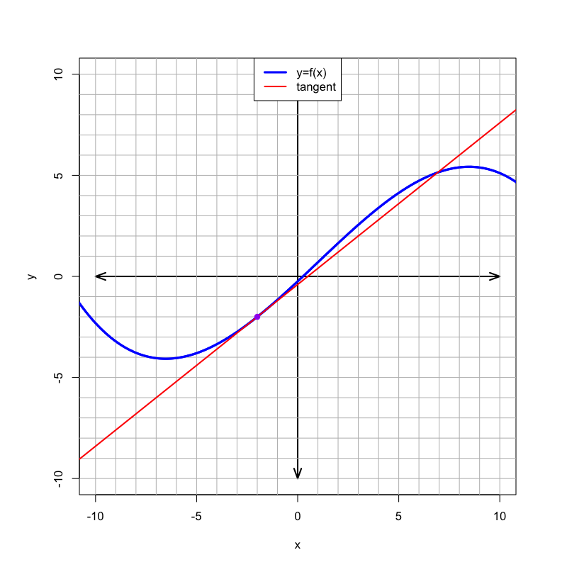

    The tangent line can be used to determine the [instantaneous rate of change](https://en.wikipedia.org/wiki/Derivative) of $f(x)$ at $x=-2$.

    Please estimate $f'(-2)$ within the nearest hundredth. This could also be notated as $\left.\frac{df(x)}{dx}\right|_{x=-2}$ or as $\frac{df}{dx}(-2)$. For more, see [wikipedia’s article on notation for differentiation](https://en.wikipedia.org/wiki/Notation_for_differentiation).

#### Solution

#### Question

38. The graph of $y=f(x)$ is shown below. Also, at $x=-2$, a [tangent line](https://en.wikipedia.org/wiki/Tangent) is drawn.

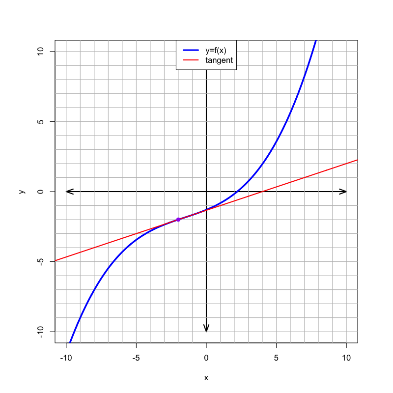

    The tangent line can be used to determine the [instantaneous rate of change](https://en.wikipedia.org/wiki/Derivative) of $f(x)$ at $x=-2$.

    Please estimate $f'(-2)$ within the nearest hundredth. This could also be notated as $\left.\frac{df(x)}{dx}\right|_{x=-2}$ or as $\frac{df}{dx}(-2)$. For more, see [wikipedia’s article on notation for differentiation](https://en.wikipedia.org/wiki/Notation_for_differentiation).

#### Solution

#### Question

39. The graph of $y=f(x)$ is shown below. Also, at $x=1$, a [tangent line](https://en.wikipedia.org/wiki/Tangent) is drawn.

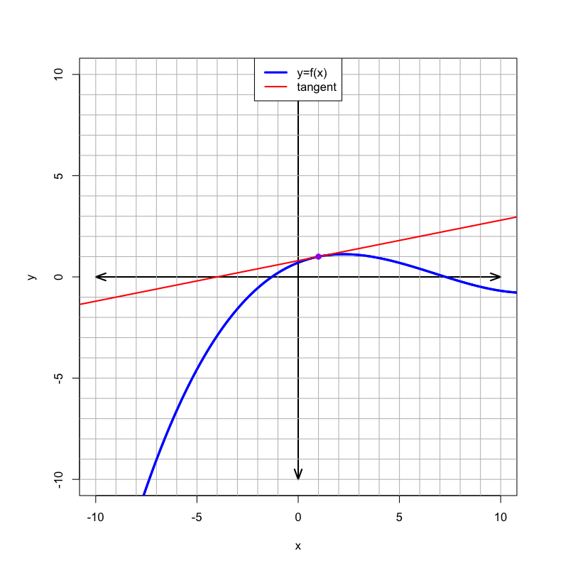

    The tangent line can be used to determine the [instantaneous rate of change](https://en.wikipedia.org/wiki/Derivative) of $f(x)$ at $x=1$.

    Please estimate $f'(1)$ within the nearest hundredth. This could also be notated as $\left.\frac{df(x)}{dx}\right|_{x=1}$ or as $\frac{df}{dx}(1)$. For more, see [wikipedia’s article on notation for differentiation](https://en.wikipedia.org/wiki/Notation_for_differentiation).

#### Solution

#### Question

40. The graph of $y=f(x)$ is shown below. Also, at $x=-2$, a [tangent line](https://en.wikipedia.org/wiki/Tangent) is drawn.

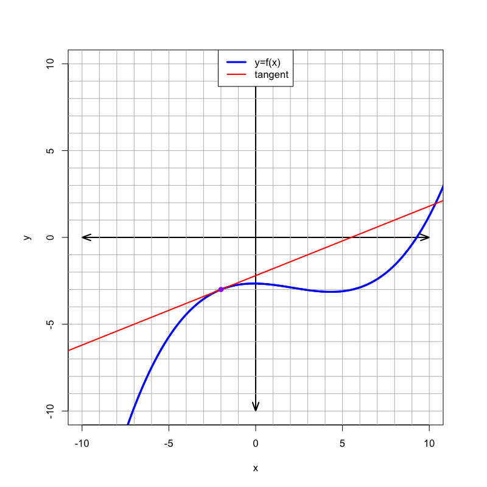

    The tangent line can be used to determine the [instantaneous rate of change](https://en.wikipedia.org/wiki/Derivative) of $f(x)$ at $x=-2$.

    Please estimate $f'(-2)$ within the nearest hundredth. This could also be notated as $\left.\frac{df(x)}{dx}\right|_{x=-2}$ or as $\frac{df}{dx}(-2)$. For more, see [wikipedia’s article on notation for differentiation](https://en.wikipedia.org/wiki/Notation_for_differentiation).

#### Solution

#### Question

41. In Calculus you will prove various [differentiation rules](https://en.wikipedia.org/wiki/Differentiation_rules). We already “proved” the [power rule](https://en.wikipedia.org/wiki/Power_rule). From here on, we will just practice using the rules (and not first prove them).

    The [rule to find the derivative of an exponential function](https://en.wikipedia.org/wiki/Differentiation_rules#Derivatives_of_exponential_and_logarithmic_functions) is shown below, where $a$ is a constant, and $\ln(a)$ is the [natural logarithm](https://en.wikipedia.org/wiki/Natural_logarithm) of $a$.

    $$f(x) ~=~ a^x$$

    $$f'(x) ~=~ a^x\cdot\ln(a)$$

    Let $g(x)=1.41^x$. Calculate $g'(2.28)$. The tolerance is $\pm 0.01$.

#### Solution

#### Question

42. In Calculus you will prove various [differentiation rules](https://en.wikipedia.org/wiki/Differentiation_rules). We already “proved” the [power rule](https://en.wikipedia.org/wiki/Power_rule). From here on, we will just practice using the rules (and not first prove them).

    The [rule to find the derivative of an exponential function](https://en.wikipedia.org/wiki/Differentiation_rules#Derivatives_of_exponential_and_logarithmic_functions) is shown below, where $a$ is a constant, and $\ln(a)$ is the [natural logarithm](https://en.wikipedia.org/wiki/Natural_logarithm) of $a$.

    $$f(x) ~=~ a^x$$

    $$f'(x) ~=~ a^x\cdot\ln(a)$$

    Let $g(x)=1.9^x$. Calculate $g'(3.03)$. The tolerance is $\pm 0.01$.

#### Solution

#### Question

43. In Calculus you will prove various [differentiation rules](https://en.wikipedia.org/wiki/Differentiation_rules). We already “proved” the [power rule](https://en.wikipedia.org/wiki/Power_rule). From here on, we will just practice using the rules (and not first prove them).

    The [rule to find the derivative of an exponential function](https://en.wikipedia.org/wiki/Differentiation_rules#Derivatives_of_exponential_and_logarithmic_functions) is shown below, where $a$ is a constant, and $\ln(a)$ is the [natural logarithm](https://en.wikipedia.org/wiki/Natural_logarithm) of $a$.

    $$f(x) ~=~ a^x$$

    $$f'(x) ~=~ a^x\cdot\ln(a)$$

    Let $g(x)=1.34^x$. Calculate $g'(4.15)$. The tolerance is $\pm 0.01$.

#### Solution

#### Question

44. In Calculus you will prove various [differentiation rules](https://en.wikipedia.org/wiki/Differentiation_rules). We already “proved” the [power rule](https://en.wikipedia.org/wiki/Power_rule). From here on, we will just practice using the rules (and not first prove them).

    The [rule to find the derivative of an exponential function](https://en.wikipedia.org/wiki/Differentiation_rules#Derivatives_of_exponential_and_logarithmic_functions) is shown below, where $a$ is a constant, and $\ln(a)$ is the [natural logarithm](https://en.wikipedia.org/wiki/Natural_logarithm) of $a$.

    $$f(x) ~=~ a^x$$

    $$f'(x) ~=~ a^x\cdot\ln(a)$$

    Let $g(x)=1.24^x$. Calculate $g'(3.76)$. The tolerance is $\pm 0.01$.

#### Solution

#### Question

45. In Calculus you will prove various [differentiation rules](https://en.wikipedia.org/wiki/Differentiation_rules). We already “proved” the [power rule](https://en.wikipedia.org/wiki/Power_rule). From here on, we will just practice using the rules (and not first prove them).

    The [rule to find the derivative of an exponential function](https://en.wikipedia.org/wiki/Differentiation_rules#Derivatives_of_exponential_and_logarithmic_functions) is shown below, where $a$ is a constant, and $\ln(a)$ is the [natural logarithm](https://en.wikipedia.org/wiki/Natural_logarithm) of $a$.

    $$f(x) ~=~ a^x$$

    $$f'(x) ~=~ a^x\cdot\ln(a)$$

    Let $g(x)=1.62^x$. Calculate $g'(3.35)$. The tolerance is $\pm 0.01$.

#### Solution

#### Question

46. A new business plans to produce and sells widgets.

    The long-run cost to produce each widget is dependent on the scale (size) of the operation. See [economies of scale](https://en.wikipedia.org/wiki/Economies_of_scale). The business models the total cost of the business with a polynomial, where $n$ is the number of widgets made and sold.
    $$C(n) ~=~ 0.000015n^3+4.1n+52000$$

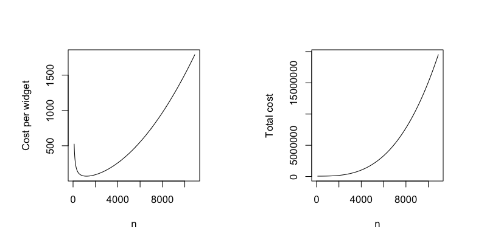

    The revenue from selling each widget is relatively constant until the scale of the operation is large enough to flood the market. The business models the revenue with another polynomial.

    $$R(n) ~=~ 1900n-0.000016n^3$$

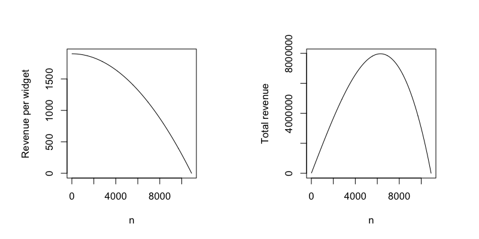

    By subtracting cost from revenue, we get a profit function.

    $$P(n) ~=~ R(n)-C(n)$$

    $$P(n) ~=~ -0.000031n^3+1895.9n-52000$$

    How many widgets should the business plan to make and sell in order to maximize profit? You can solve this by finding the special number, $n^\star$, such that $P'(n^\star)=0$.

    The tolerance is $\pm 10$ widgets.

#### Solution

#### Question

47. A new business plans to produce and sells widgets.

    The long-run cost to produce each widget is dependent on the scale (size) of the operation. See [economies of scale](https://en.wikipedia.org/wiki/Economies_of_scale). The business models the total cost of the business with a polynomial, where $n$ is the number of widgets made and sold.
    $$C(n) ~=~ 0.00012n^3+920n+1700000$$

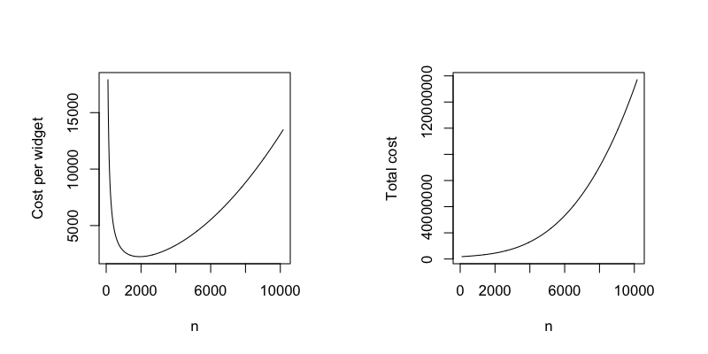

    The revenue from selling each widget is relatively constant until the scale of the operation is large enough to flood the market. The business models the revenue with another polynomial.

    $$R(n) ~=~ 310000n-0.003n^3$$

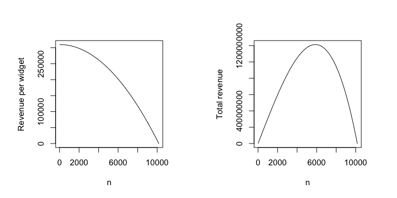

    By subtracting cost from revenue, we get a profit function.

    $$P(n) ~=~ R(n)-C(n)$$

    $$P(n) ~=~ -0.00312n^3+309080n-1700000$$

    How many widgets should the business plan to make and sell in order to maximize profit? You can solve this by finding the special number, $n^\star$, such that $P'(n^\star)=0$.

    The tolerance is $\pm 10$ widgets.

#### Solution

#### Question

48. A new business plans to produce and sells widgets.

    The long-run cost to produce each widget is dependent on the scale (size) of the operation. See [economies of scale](https://en.wikipedia.org/wiki/Economies_of_scale). The business models the total cost of the business with a polynomial, where $n$ is the number of widgets made and sold.
    $$C(n) ~=~ 0.000067n^3+400n+8800000$$

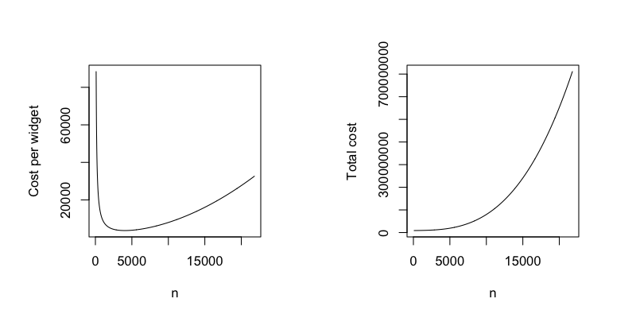

    The revenue from selling each widget is relatively constant until the scale of the operation is large enough to flood the market. The business models the revenue with another polynomial.

    $$R(n) ~=~ 57000n-0.00012n^3$$

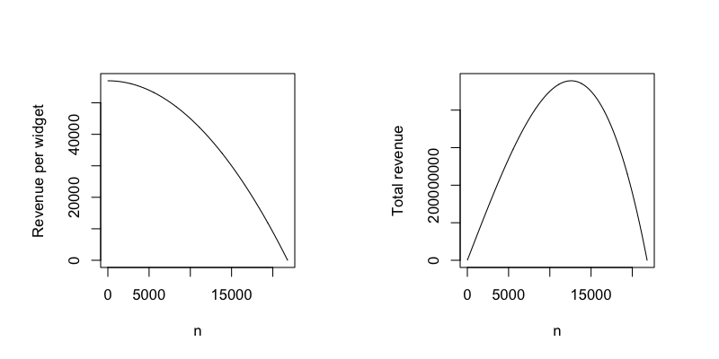

    By subtracting cost from revenue, we get a profit function.

    $$P(n) ~=~ R(n)-C(n)$$

    $$P(n) ~=~ -0.000187n^3+56600n-8800000$$

    How many widgets should the business plan to make and sell in order to maximize profit? You can solve this by finding the special number, $n^\star$, such that $P'(n^\star)=0$.

    The tolerance is $\pm 10$ widgets.

#### Solution

#### Question

49. A new business plans to produce and sells widgets.

    The long-run cost to produce each widget is dependent on the scale (size) of the operation. See [economies of scale](https://en.wikipedia.org/wiki/Economies_of_scale). The business models the total cost of the business with a polynomial, where $n$ is the number of widgets made and sold.
    $$C(n) ~=~ 0.00087n^3+3300n+1300000$$

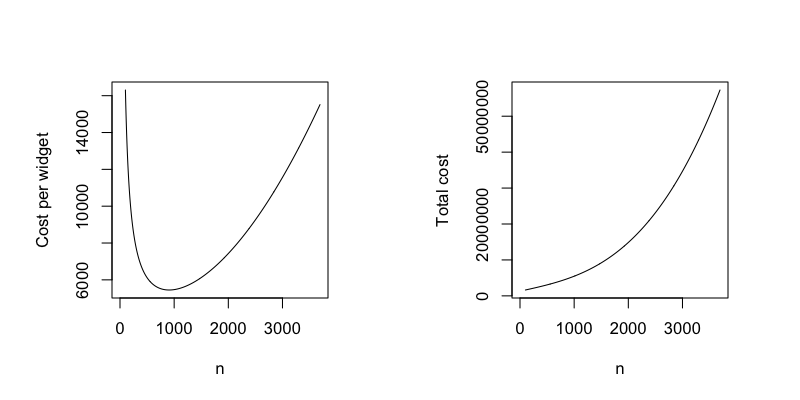

    The revenue from selling each widget is relatively constant until the scale of the operation is large enough to flood the market. The business models the revenue with another polynomial.

    $$R(n) ~=~ 1500000n-0.11n^3$$

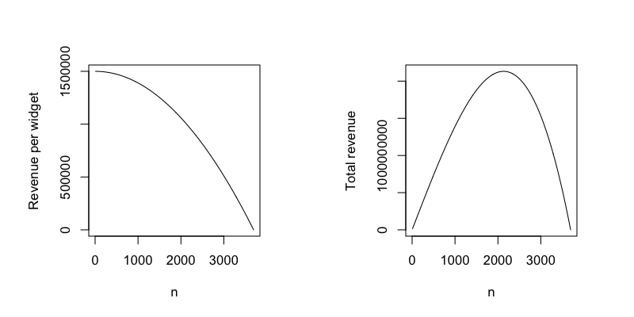

    By subtracting cost from revenue, we get a profit function.

    $$P(n) ~=~ R(n)-C(n)$$

    $$P(n) ~=~ -0.11087n^3+1496700n-1300000$$

    How many widgets should the business plan to make and sell in order to maximize profit? You can solve this by finding the special number, $n^\star$, such that $P'(n^\star)=0$.

    The tolerance is $\pm 10$ widgets.

#### Solution

#### Question

50. A new business plans to produce and sells widgets.

    The long-run cost to produce each widget is dependent on the scale (size) of the operation. See [economies of scale](https://en.wikipedia.org/wiki/Economies_of_scale). The business models the total cost of the business with a polynomial, where $n$ is the number of widgets made and sold.
    $$C(n) ~=~ 0.0012n^3+13n+3200000$$

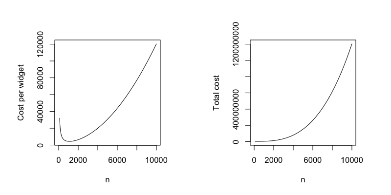

    The revenue from selling each widget is relatively constant until the scale of the operation is large enough to flood the market. The business models the revenue with another polynomial.

    $$R(n) ~=~ 11000n-0.00011n^3$$

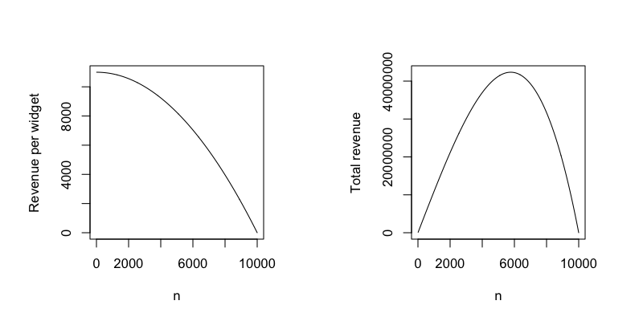

    By subtracting cost from revenue, we get a profit function.

    $$P(n) ~=~ R(n)-C(n)$$

    $$P(n) ~=~ -0.00131n^3+10987n-3200000$$

    How many widgets should the business plan to make and sell in order to maximize profit? You can solve this by finding the special number, $n^\star$, such that $P'(n^\star)=0$.

    The tolerance is $\pm 10$ widgets.

#### Solution

#### Question

51. A designer plans to manufacture open-top cylinders by using 27.3 grams of aluminum for each cylinder. The base uses 0.05 grams per square centimeter. The sides use 0.02 grams per square centimeter. The goal is to produce a cylinder that holds as much volume as possible. How tall, in centimeters, should the cylinder be?

    The tolerance is $\pm 0.1$ cm.

#### Solution

#### Question

52. A designer plans to manufacture open-top cylinders by using 76.4 grams of aluminum for each cylinder. The base uses 0.69 grams per square centimeter. The sides use 0.5 grams per square centimeter. The goal is to produce a cylinder that holds as much volume as possible. How tall, in centimeters, should the cylinder be?

    The tolerance is $\pm 0.1$ cm.

#### Solution

#### Question

53. A designer plans to manufacture open-top cylinders by using 16.8 grams of aluminum for each cylinder. The base uses 0.06 grams per square centimeter. The sides use 0.03 grams per square centimeter. The goal is to produce a cylinder that holds as much volume as possible. How tall, in centimeters, should the cylinder be?

    The tolerance is $\pm 0.1$ cm.

#### Solution

#### Question

54. A designer plans to manufacture open-top cylinders by using 6.4 grams of aluminum for each cylinder. The base uses 0.05 grams per square centimeter. The sides use 0.02 grams per square centimeter. The goal is to produce a cylinder that holds as much volume as possible. How tall, in centimeters, should the cylinder be?

    The tolerance is $\pm 0.1$ cm.

#### Solution

#### Question

55. A designer plans to manufacture open-top cylinders by using 25 grams of aluminum for each cylinder. The base uses 0.06 grams per square centimeter. The sides use 0.05 grams per square centimeter. The goal is to produce a cylinder that holds as much volume as possible. How tall, in centimeters, should the cylinder be?

    The tolerance is $\pm 0.1$ cm.

#### Solution

#### Question

56. Which graph shows a correct pair of $f(x)$ as a blue curve and $f'(x)$ as a red curve? Remember the output ($y$) of the red [derivative function](https://en.wikipedia.org/wiki/Derivative) should match the instantaneous slope of the blue curve for all values of $x$.

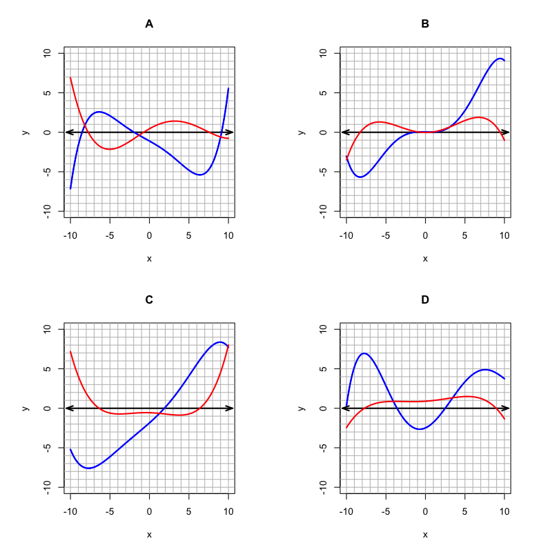

    1. A
    2. B
    3. C
    4. D

#### Solution

#### Question

57. Which graph shows a correct pair of $f(x)$ as a blue curve and $f'(x)$ as a red curve? Remember the output ($y$) of the red [derivative function](https://en.wikipedia.org/wiki/Derivative) should match the instantaneous slope of the blue curve for all values of $x$.

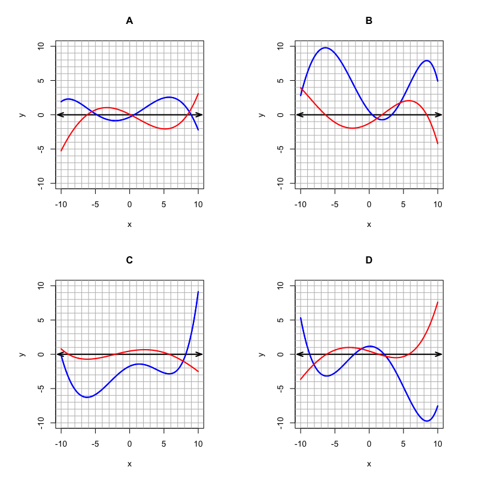

    1. A
    2. B
    3. C
    4. D

#### Solution

#### Question

58. Which graph shows a correct pair of $f(x)$ as a blue curve and $f'(x)$ as a red curve? Remember the output ($y$) of the red [derivative function](https://en.wikipedia.org/wiki/Derivative) should match the instantaneous slope of the blue curve for all values of $x$.

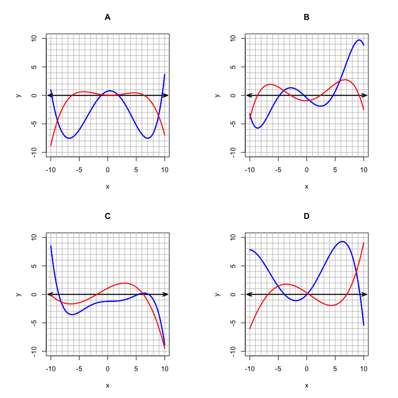

    1. A
    2. B
    3. C
    4. D

#### Solution

#### Question

59. Which graph shows a correct pair of $f(x)$ as a blue curve and $f'(x)$ as a red curve? Remember the output ($y$) of the red [derivative function](https://en.wikipedia.org/wiki/Derivative) should match the instantaneous slope of the blue curve for all values of $x$.

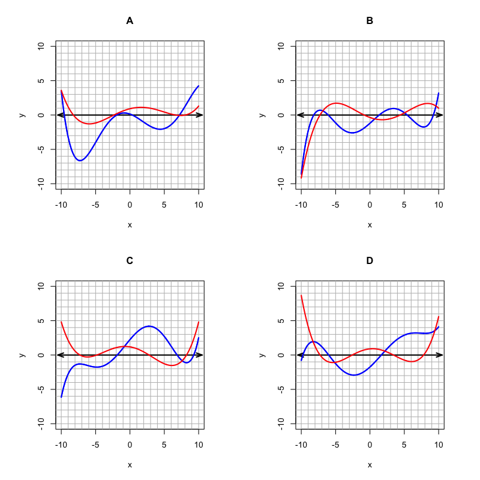

    1. A
    2. B
    3. C
    4. D

#### Solution

#### Question

60. Which graph shows a correct pair of $f(x)$ as a blue curve and $f'(x)$ as a red curve? Remember the output ($y$) of the red [derivative function](https://en.wikipedia.org/wiki/Derivative) should match the instantaneous slope of the blue curve for all values of $x$.

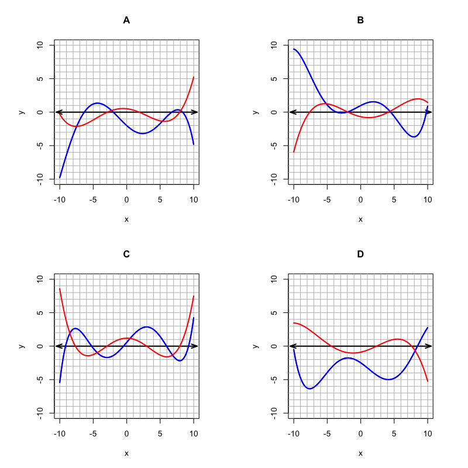

    1. A
    2. B
    3. C
    4. D

#### Solution

#### Question

61. The [product rule](https://en.wikipedia.org/wiki/Differentiation_rules#The_product_rule) tells us that if $f(x)=g(x)\cdot h(x)$, then

    $$f'(x)~=~g'(x)\cdot h(x) ~+~ g(x)\cdot h'(x)$$

    Let’s practice using the product rule along with the [power rule](https://en.wikipedia.org/wiki/Differentiation_rules#The_polynomial_or_elementary_power_rule) and the [exponential rule](https://en.wikipedia.org/wiki/Differentiation_rules#Derivatives_of_exponential_and_logarithmic_functions).

    Let function $f$ be defined below.
    $$f(x)~=~x^{2.9}\cdot 2.7^x$$

    Evaluate $f'(4.5)$. The tolerance is $\pm 1$.

#### Solution

#### Question

62. The [product rule](https://en.wikipedia.org/wiki/Differentiation_rules#The_product_rule) tells us that if $f(x)=g(x)\cdot h(x)$, then

    $$f'(x)~=~g'(x)\cdot h(x) ~+~ g(x)\cdot h'(x)$$

    Let’s practice using the product rule along with the [power rule](https://en.wikipedia.org/wiki/Differentiation_rules#The_polynomial_or_elementary_power_rule) and the [exponential rule](https://en.wikipedia.org/wiki/Differentiation_rules#Derivatives_of_exponential_and_logarithmic_functions).

    Let function $f$ be defined below.
    $$f(x)~=~x^{5.7}\cdot 4.8^x$$

    Evaluate $f'(2.3)$. The tolerance is $\pm 1$.

#### Solution

#### Question

63. The [product rule](https://en.wikipedia.org/wiki/Differentiation_rules#The_product_rule) tells us that if $f(x)=g(x)\cdot h(x)$, then

    $$f'(x)~=~g'(x)\cdot h(x) ~+~ g(x)\cdot h'(x)$$

    Let’s practice using the product rule along with the [power rule](https://en.wikipedia.org/wiki/Differentiation_rules#The_polynomial_or_elementary_power_rule) and the [exponential rule](https://en.wikipedia.org/wiki/Differentiation_rules#Derivatives_of_exponential_and_logarithmic_functions).

    Let function $f$ be defined below.
    $$f(x)~=~x^{2.3}\cdot 2.1^x$$

    Evaluate $f'(1.9)$. The tolerance is $\pm 1$.

#### Solution

#### Question

64. The [product rule](https://en.wikipedia.org/wiki/Differentiation_rules#The_product_rule) tells us that if $f(x)=g(x)\cdot h(x)$, then

    $$f'(x)~=~g'(x)\cdot h(x) ~+~ g(x)\cdot h'(x)$$

    Let’s practice using the product rule along with the [power rule](https://en.wikipedia.org/wiki/Differentiation_rules#The_polynomial_or_elementary_power_rule) and the [exponential rule](https://en.wikipedia.org/wiki/Differentiation_rules#Derivatives_of_exponential_and_logarithmic_functions).

    Let function $f$ be defined below.
    $$f(x)~=~x^{5.5}\cdot 1.3^x$$

    Evaluate $f'(1.7)$. The tolerance is $\pm 1$.

#### Solution

#### Question

65. The [product rule](https://en.wikipedia.org/wiki/Differentiation_rules#The_product_rule) tells us that if $f(x)=g(x)\cdot h(x)$, then

    $$f'(x)~=~g'(x)\cdot h(x) ~+~ g(x)\cdot h'(x)$$

    Let’s practice using the product rule along with the [power rule](https://en.wikipedia.org/wiki/Differentiation_rules#The_polynomial_or_elementary_power_rule) and the [exponential rule](https://en.wikipedia.org/wiki/Differentiation_rules#Derivatives_of_exponential_and_logarithmic_functions).

    Let function $f$ be defined below.
    $$f(x)~=~x^{7}\cdot 2.4^x$$

    Evaluate $f'(1.7)$. The tolerance is $\pm 1$.

#### Solution

#### Question

66. The area of a rectangle is the product of its width and height. A rectangle is growing both horizontally and vertically, so that both width and height are functions of time.

    $$A(t) ~=~ w(t)\cdot h(t)$$

    At $t=3$ seconds, the width is 5.96 meters, and the height is 8.52 meters.

    $$w(3)=5.96$$
    $$h(3)=8.52$$

    Over a small interval of time ($\Delta t = 0.01$ seconds) the rectangle’s width grows by $\Delta w=0.04$ meters and the height grows by $\Delta h =0.07$ meters, so $w(3.01)=6$ and $h(3.01)=8.59$. This is depicted below (not drawn to scale).

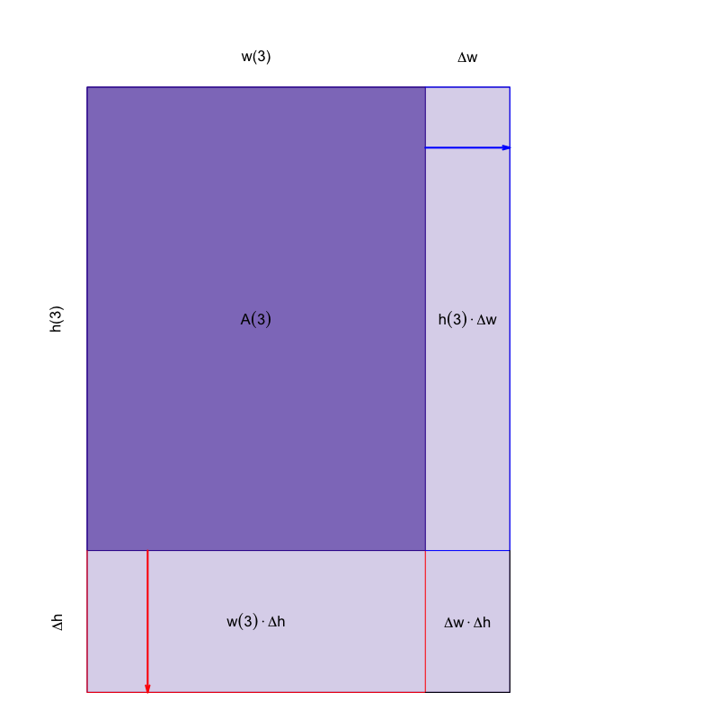

    By calculating various values, we will explore the fact that if $\Delta w$ and $\Delta h$ are quite small compared to $w$ and $h$, then the area $\Delta w\cdot \Delta h$ is so small that we can ignore it for many purposes. In the process, we will “prove” the [product rule](https://en.wikipedia.org/wiki/Differentiation_rules#The_product_rule).

    Find the area of the rectangle at $t=3$.
    - $A(3)=$ $\mathrm{m^2}$

    Find the other areas in the diagram.
    - $h(3) \Delta w=$ $\mathrm{m^2}$
    - $w(3) \Delta h=$ $\mathrm{m^2}$
    - $\Delta w \Delta h=$ $\mathrm{m^2}$

    How much did the area grow by?
    - $\Delta A ~=~ A(3.01)-A(3) ~=~$ $\mathrm{m^2}$

    What would be the estimated growth of area if we ignored the smallest area?
    - $h(3)\Delta w + w(3)\Delta h=$ $\mathrm{m^2}$

    Find the final area of the rectangle.
    - $A(3.01)=$ $\mathrm{m^2}$

    What would be the estimated final area of the rectangle if you ignored the smallest area?
    - $A(3)+h(3)\Delta w + w(3)\Delta h=$ $\mathrm{m^2}$

    How fast (on average) are the width and height growing between $t=3$ and $t=3.01$?
    - $\frac{\Delta w}{\Delta t} =$ $\mathrm{\frac{m}{s}}$
    - $\frac{\Delta h}{\Delta t} =$ $\mathrm{\frac{m}{s}}$

    What is the average rate of growth of the rectangle’s area between $t=3$ and $t=3.01$?
    - $\frac{\Delta A}{\Delta t}=$ $\mathrm{\frac{m^2}{s}}$

    What would be the estimated rate of growth if we ignored the smallest area?
    - $h\cdot \frac{\Delta w}{\Delta t}~+~w\cdot \frac{\Delta h}{\Delta t}=$ $\mathrm{\frac{m^2}{s}}$

#### Solution

#### Question

67. The area of a rectangle is the product of its width and height. A rectangle is growing both horizontally and vertically, so that both width and height are functions of time.

    $$A(t) ~=~ w(t)\cdot h(t)$$

    At $t=2$ seconds, the width is 9.6 meters, and the height is 7.37 meters.

    $$w(2)=9.6$$
    $$h(2)=7.37$$

    Over a small interval of time ($\Delta t = 0.01$ seconds) the rectangle’s width grows by $\Delta w=0.07$ meters and the height grows by $\Delta h =0.04$ meters, so $w(2.01)=9.67$ and $h(2.01)=7.41$. This is depicted below (not drawn to scale).

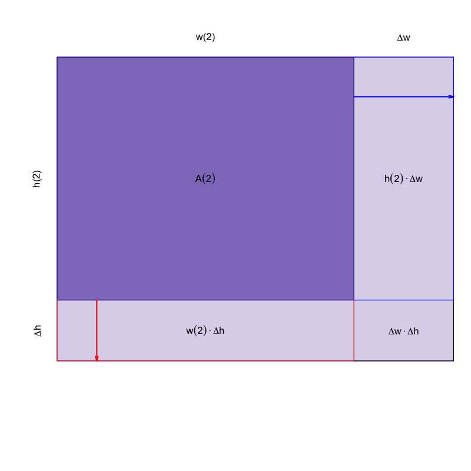

    By calculating various values, we will explore the fact that if $\Delta w$ and $\Delta h$ are quite small compared to $w$ and $h$, then the area $\Delta w\cdot \Delta h$ is so small that we can ignore it for many purposes. In the process, we will “prove” the [product rule](https://en.wikipedia.org/wiki/Differentiation_rules#The_product_rule).

    Find the area of the rectangle at $t=2$.
    - $A(2)=$ $\mathrm{m^2}$

    Find the other areas in the diagram.
    - $h(2) \Delta w=$ $\mathrm{m^2}$
    - $w(2) \Delta h=$ $\mathrm{m^2}$
    - $\Delta w \Delta h=$ $\mathrm{m^2}$

    How much did the area grow by?
    - $\Delta A ~=~ A(2.01)-A(2) ~=~$ $\mathrm{m^2}$

    What would be the estimated growth of area if we ignored the smallest area?
    - $h(2)\Delta w + w(2)\Delta h=$ $\mathrm{m^2}$

    Find the final area of the rectangle.
    - $A(2.01)=$ $\mathrm{m^2}$

    What would be the estimated final area of the rectangle if you ignored the smallest area?
    - $A(2)+h(2)\Delta w + w(2)\Delta h=$ $\mathrm{m^2}$

    How fast (on average) are the width and height growing between $t=2$ and $t=2.01$?
    - $\frac{\Delta w}{\Delta t} =$ $\mathrm{\frac{m}{s}}$
    - $\frac{\Delta h}{\Delta t} =$ $\mathrm{\frac{m}{s}}$

    What is the average rate of growth of the rectangle’s area between $t=2$ and $t=2.01$?
    - $\frac{\Delta A}{\Delta t}=$ $\mathrm{\frac{m^2}{s}}$

    What would be the estimated rate of growth if we ignored the smallest area?
    - $h\cdot \frac{\Delta w}{\Delta t}~+~w\cdot \frac{\Delta h}{\Delta t}=$ $\mathrm{\frac{m^2}{s}}$

#### Solution

#### Question

68. The area of a rectangle is the product of its width and height. A rectangle is growing both horizontally and vertically, so that both width and height are functions of time.

    $$A(t) ~=~ w(t)\cdot h(t)$$

    At $t=5$ seconds, the width is 8.55 meters, and the height is 9.84 meters.

    $$w(5)=8.55$$
    $$h(5)=9.84$$

    Over a small interval of time ($\Delta t = 0.01$ seconds) the rectangle’s width grows by $\Delta w=0.04$ meters and the height grows by $\Delta h =0.11$ meters, so $w(5.01)=8.59$ and $h(5.01)=9.95$. This is depicted below (not drawn to scale).

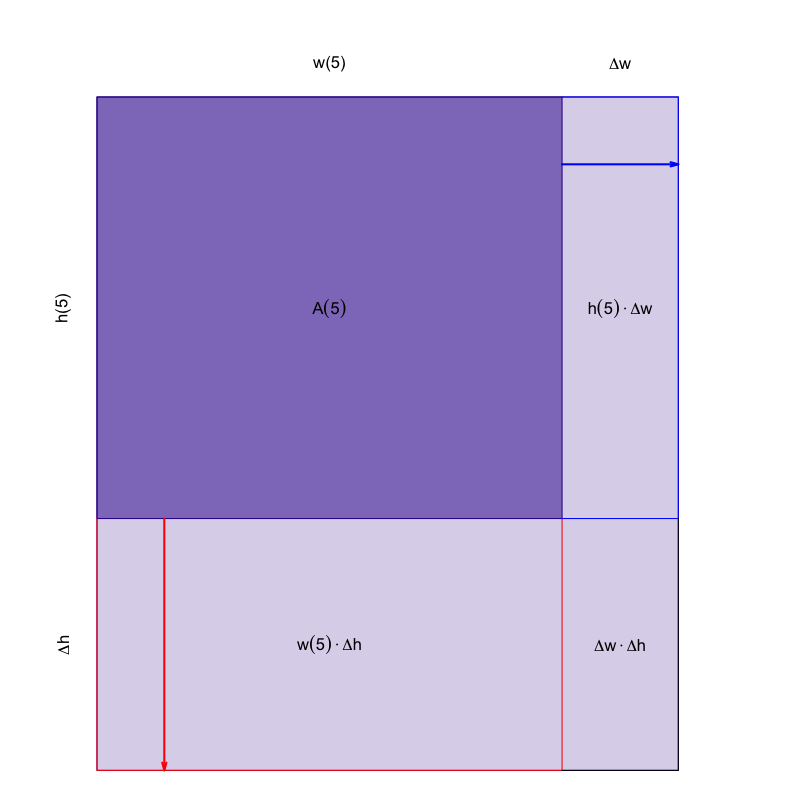

    By calculating various values, we will explore the fact that if $\Delta w$ and $\Delta h$ are quite small compared to $w$ and $h$, then the area $\Delta w\cdot \Delta h$ is so small that we can ignore it for many purposes. In the process, we will “prove” the [product rule](https://en.wikipedia.org/wiki/Differentiation_rules#The_product_rule).

    Find the area of the rectangle at $t=5$.
    - $A(5)=$ $\mathrm{m^2}$

    Find the other areas in the diagram.
    - $h(5) \Delta w=$ $\mathrm{m^2}$
    - $w(5) \Delta h=$ $\mathrm{m^2}$
    - $\Delta w \Delta h=$ $\mathrm{m^2}$

    How much did the area grow by?
    - $\Delta A ~=~ A(5.01)-A(5) ~=~$ $\mathrm{m^2}$

    What would be the estimated growth of area if we ignored the smallest area?
    - $h(5)\Delta w + w(5)\Delta h=$ $\mathrm{m^2}$

    Find the final area of the rectangle.
    - $A(5.01)=$ $\mathrm{m^2}$

    What would be the estimated final area of the rectangle if you ignored the smallest area?
    - $A(5)+h(5)\Delta w + w(5)\Delta h=$ $\mathrm{m^2}$

    How fast (on average) are the width and height growing between $t=5$ and $t=5.01$?
    - $\frac{\Delta w}{\Delta t} =$ $\mathrm{\frac{m}{s}}$
    - $\frac{\Delta h}{\Delta t} =$ $\mathrm{\frac{m}{s}}$

    What is the average rate of growth of the rectangle’s area between $t=5$ and $t=5.01$?
    - $\frac{\Delta A}{\Delta t}=$ $\mathrm{\frac{m^2}{s}}$

    What would be the estimated rate of growth if we ignored the smallest area?
    - $h\cdot \frac{\Delta w}{\Delta t}~+~w\cdot \frac{\Delta h}{\Delta t}=$ $\mathrm{\frac{m^2}{s}}$

#### Solution

#### Question

69. The area of a rectangle is the product of its width and height. A rectangle is growing both horizontally and vertically, so that both width and height are functions of time.

    $$A(t) ~=~ w(t)\cdot h(t)$$

    At $t=8$ seconds, the width is 9.81 meters, and the height is 6.63 meters.

    $$w(8)=9.81$$
    $$h(8)=6.63$$

    Over a small interval of time ($\Delta t = 0.01$ seconds) the rectangle’s width grows by $\Delta w=0.05$ meters and the height grows by $\Delta h =0.07$ meters, so $w(8.01)=9.86$ and $h(8.01)=6.7$. This is depicted below (not drawn to scale).

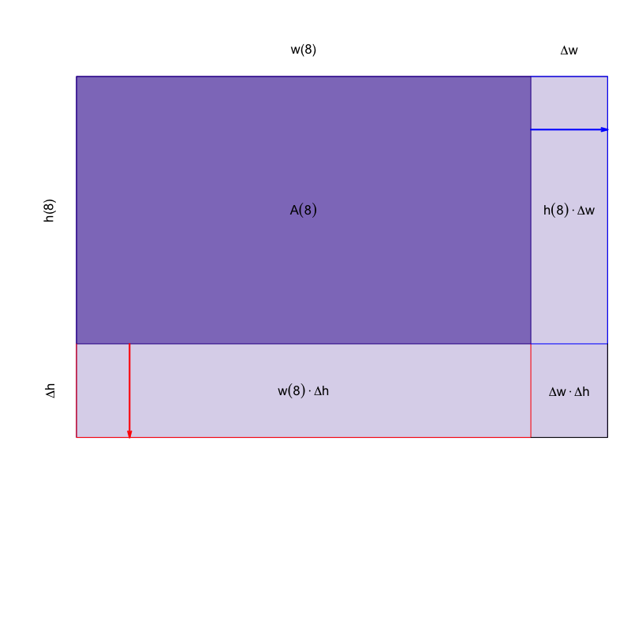

    By calculating various values, we will explore the fact that if $\Delta w$ and $\Delta h$ are quite small compared to $w$ and $h$, then the area $\Delta w\cdot \Delta h$ is so small that we can ignore it for many purposes. In the process, we will “prove” the [product rule](https://en.wikipedia.org/wiki/Differentiation_rules#The_product_rule).

    Find the area of the rectangle at $t=8$.
    - $A(8)=$ $\mathrm{m^2}$

    Find the other areas in the diagram.
    - $h(8) \Delta w=$ $\mathrm{m^2}$
    - $w(8) \Delta h=$ $\mathrm{m^2}$
    - $\Delta w \Delta h=$ $\mathrm{m^2}$

    How much did the area grow by?
    - $\Delta A ~=~ A(8.01)-A(8) ~=~$ $\mathrm{m^2}$

    What would be the estimated growth of area if we ignored the smallest area?
    - $h(8)\Delta w + w(8)\Delta h=$ $\mathrm{m^2}$

    Find the final area of the rectangle.
    - $A(8.01)=$ $\mathrm{m^2}$

    What would be the estimated final area of the rectangle if you ignored the smallest area?
    - $A(8)+h(8)\Delta w + w(8)\Delta h=$ $\mathrm{m^2}$

    How fast (on average) are the width and height growing between $t=8$ and $t=8.01$?
    - $\frac{\Delta w}{\Delta t} =$ $\mathrm{\frac{m}{s}}$
    - $\frac{\Delta h}{\Delta t} =$ $\mathrm{\frac{m}{s}}$

    What is the average rate of growth of the rectangle’s area between $t=8$ and $t=8.01$?
    - $\frac{\Delta A}{\Delta t}=$ $\mathrm{\frac{m^2}{s}}$

    What would be the estimated rate of growth if we ignored the smallest area?
    - $h\cdot \frac{\Delta w}{\Delta t}~+~w\cdot \frac{\Delta h}{\Delta t}=$ $\mathrm{\frac{m^2}{s}}$

#### Solution

#### Question

70. The area of a rectangle is the product of its width and height. A rectangle is growing both horizontally and vertically, so that both width and height are functions of time.

    $$A(t) ~=~ w(t)\cdot h(t)$$

    At $t=8$ seconds, the width is 6.61 meters, and the height is 8.37 meters.

    $$w(8)=6.61$$
    $$h(8)=8.37$$

    Over a small interval of time ($\Delta t = 0.01$ seconds) the rectangle’s width grows by $\Delta w=0.11$ meters and the height grows by $\Delta h =0.04$ meters, so $w(8.01)=6.72$ and $h(8.01)=8.41$. This is depicted below (not drawn to scale).

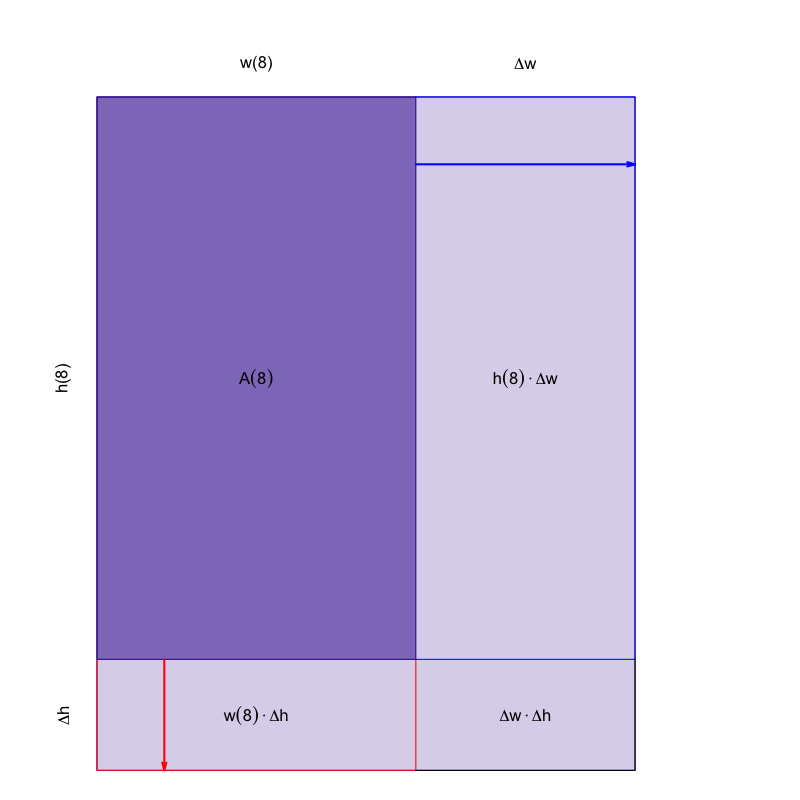

    By calculating various values, we will explore the fact that if $\Delta w$ and $\Delta h$ are quite small compared to $w$ and $h$, then the area $\Delta w\cdot \Delta h$ is so small that we can ignore it for many purposes. In the process, we will “prove” the [product rule](https://en.wikipedia.org/wiki/Differentiation_rules#The_product_rule).

    Find the area of the rectangle at $t=8$.
    - $A(8)=$ $\mathrm{m^2}$

    Find the other areas in the diagram.
    - $h(8) \Delta w=$ $\mathrm{m^2}$
    - $w(8) \Delta h=$ $\mathrm{m^2}$
    - $\Delta w \Delta h=$ $\mathrm{m^2}$

    How much did the area grow by?
    - $\Delta A ~=~ A(8.01)-A(8) ~=~$ $\mathrm{m^2}$

    What would be the estimated growth of area if we ignored the smallest area?
    - $h(8)\Delta w + w(8)\Delta h=$ $\mathrm{m^2}$

    Find the final area of the rectangle.
    - $A(8.01)=$ $\mathrm{m^2}$

    What would be the estimated final area of the rectangle if you ignored the smallest area?
    - $A(8)+h(8)\Delta w + w(8)\Delta h=$ $\mathrm{m^2}$

    How fast (on average) are the width and height growing between $t=8$ and $t=8.01$?
    - $\frac{\Delta w}{\Delta t} =$ $\mathrm{\frac{m}{s}}$
    - $\frac{\Delta h}{\Delta t} =$ $\mathrm{\frac{m}{s}}$

    What is the average rate of growth of the rectangle’s area between $t=8$ and $t=8.01$?
    - $\frac{\Delta A}{\Delta t}=$ $\mathrm{\frac{m^2}{s}}$

    What would be the estimated rate of growth if we ignored the smallest area?
    - $h\cdot \frac{\Delta w}{\Delta t}~+~w\cdot \frac{\Delta h}{\Delta t}=$ $\mathrm{\frac{m^2}{s}}$

#### Solution

#### Question

71. Let $f(x)=x^3-6x^2-28x-30$. A tangent line is drawn through $(-2, -6)$. Find the equation of the tangent line in slope-intercept form ($y=mx+b$).
    - $m=$
    - $b=$

#### Solution

#### Question

72. Let $f(x)=x^3+6x^2+8x+7$. A tangent line is drawn through $(-2, 7)$. Find the equation of the tangent line in slope-intercept form ($y=mx+b$).
    - $m=$
    - $b=$

#### Solution

#### Question

73. Let $f(x)=x^3-x^2-18x+44$. A tangent line is drawn through $(3, 8)$. Find the equation of the tangent line in slope-intercept form ($y=mx+b$).
    - $m=$
    - $b=$

#### Solution

#### Question

74. Let $f(x)=3x^3+9x^2+10x-5$. A tangent line is drawn through $(-2, -13)$. Find the equation of the tangent line in slope-intercept form ($y=mx+b$).
    - $m=$
    - $b=$

#### Solution

#### Question

75. Let $f(x)=x^3-9x^2+23x-25$. A tangent line is drawn through $(3, -10)$. Find the equation of the tangent line in slope-intercept form ($y=mx+b$).
    - $m=$
    - $b=$

#### Solution

#### Question

76. A chef is deciding how much salt to add to a dish. They’ve determined that [utility](https://en.wikipedia.org/wiki/Utility) ($u$ in “utils”) is a function of the mass of salt ($x$ in grams).

    $$u(x) = 2x^{6}-6x^{10}$$

    What is the optimal mass of salt to maximize utility? (You can assume only positive amounts of salt are possible. The tolerance is $\pm0.01$ grams.)

#### Solution

#### Question

77. A chef is deciding how much salt to add to a dish. They’ve determined that [utility](https://en.wikipedia.org/wiki/Utility) ($u$ in “utils”) is a function of the mass of salt ($x$ in grams).

    $$u(x) = 8x^{3}-4x^{10}$$

    What is the optimal mass of salt to maximize utility? (You can assume only positive amounts of salt are possible. The tolerance is $\pm0.01$ grams.)

#### Solution

#### Question

78. A chef is deciding how much salt to add to a dish. They’ve determined that [utility](https://en.wikipedia.org/wiki/Utility) ($u$ in “utils”) is a function of the mass of salt ($x$ in grams).

    $$u(x) = 3x^{3}-2x^{10}$$

    What is the optimal mass of salt to maximize utility? (You can assume only positive amounts of salt are possible. The tolerance is $\pm0.01$ grams.)

#### Solution

#### Question

79. A chef is deciding how much salt to add to a dish. They’ve determined that [utility](https://en.wikipedia.org/wiki/Utility) ($u$ in “utils”) is a function of the mass of salt ($x$ in grams).

    $$u(x) = 8x^{3}-2x^{7}$$

    What is the optimal mass of salt to maximize utility? (You can assume only positive amounts of salt are possible. The tolerance is $\pm0.01$ grams.)

#### Solution

#### Question

80. A chef is deciding how much salt to add to a dish. They’ve determined that [utility](https://en.wikipedia.org/wiki/Utility) ($u$ in “utils”) is a function of the mass of salt ($x$ in grams).

    $$u(x) = 9x^{4}-5x^{8}$$

    What is the optimal mass of salt to maximize utility? (You can assume only positive amounts of salt are possible. The tolerance is $\pm0.01$ grams.)

#### Solution